title: “Reproducible Research Course - Peer Assessment 1” author: “Created by Fang” date: “Saturday, June 13, 2015” output: html_document keep_md: true

## Step 1: Setting Global Options

```
       - notes: couldn't get knit2html() works, so no figure folder uploaded to github
```

```r
library(knitr)
opts_chunk$set(echo = FALSE) #remove
```

## Step 2: Set Working Directory to where the repo was cloned

```r
setwd("C:/Users/fangl_000/Documents/GitHub/RepData_PeerAssessment1")
getwd()
```

```
## [1] "C:/Users/fangl_000/Documents/GitHub/RepData_PeerAssessment1"
```

## Step 3: unzip and load the data

```r
unzip("activity.zip")
mydata <- read.csv("activity.csv", colClasses = c("integer", "Date", "factor"))
head(mydata)
```

```
##   steps       date interval
## 1    NA 2012-10-01        0
## 2    NA 2012-10-01        5
## 3    NA 2012-10-01       10
## 4    NA 2012-10-01       15
## 5    NA 2012-10-01       20
## 6    NA 2012-10-01       25
```

```r
dim(mydata)
```

```
## [1] 17568     3
```

```r
summary(mydata)
```

```
##      steps             date               interval
##  Min.   :  0.00   Min.   :2012-10-01   0      :   61
##  1st Qu.:  0.00   1st Qu.:2012-10-16   10     :   61
##  Median :  0.00   Median :2012-10-31   100    :   61
##  Mean   : 37.38   Mean   :2012-10-31   1000   :   61
##  3rd Qu.: 12.00   3rd Qu.:2012-11-15   1005   :   61
##  Max.   :806.00   Max.   :2012-11-30   1010   :   61
##  NA's   :2304                          (Other):17202
```

## Step 4: Clean and preprocess the data, create a data without missing value for steps

```
##   steps       date interval month day year
## 1    NA 2012-10-01        0    10   1   12
## 2    NA 2012-10-01        5    10   1   12
## 3    NA 2012-10-01       10    10   1   12
## 4    NA 2012-10-01       15    10   1   12
## 5    NA 2012-10-01       20    10   1   12
## 6    NA 2012-10-01       25    10   1   12
```

## Step 5: What is mean total number of steps taken per day?

### For this part of the assignment, you can ignore the missing values in the dataset.

1. Calculate the total number of steps taken per day
2. Make a histogram of the total number of steps taken each day
3. Calculate and report the mean and median of the total number of steps taken per day

```
##  [1]   126 11352 12116 13294 15420 11015 12811  9900 10304 17382 12426
## [12] 15098 10139 15084 13452 10056 11829 10395  8821 13460  8918  8355
## [23]  2492  6778 10119 11458  5018  9819 15414 10600 10571 10439  8334
## [34] 12883  3219 12608 10765  7336    41  5441 14339 15110  8841  4472
## [45] 12787 20427 21194 14478 11834 11162 13646 10183  7047
```

```
## [1] 10766.19
```

```
## [1] 10765
```

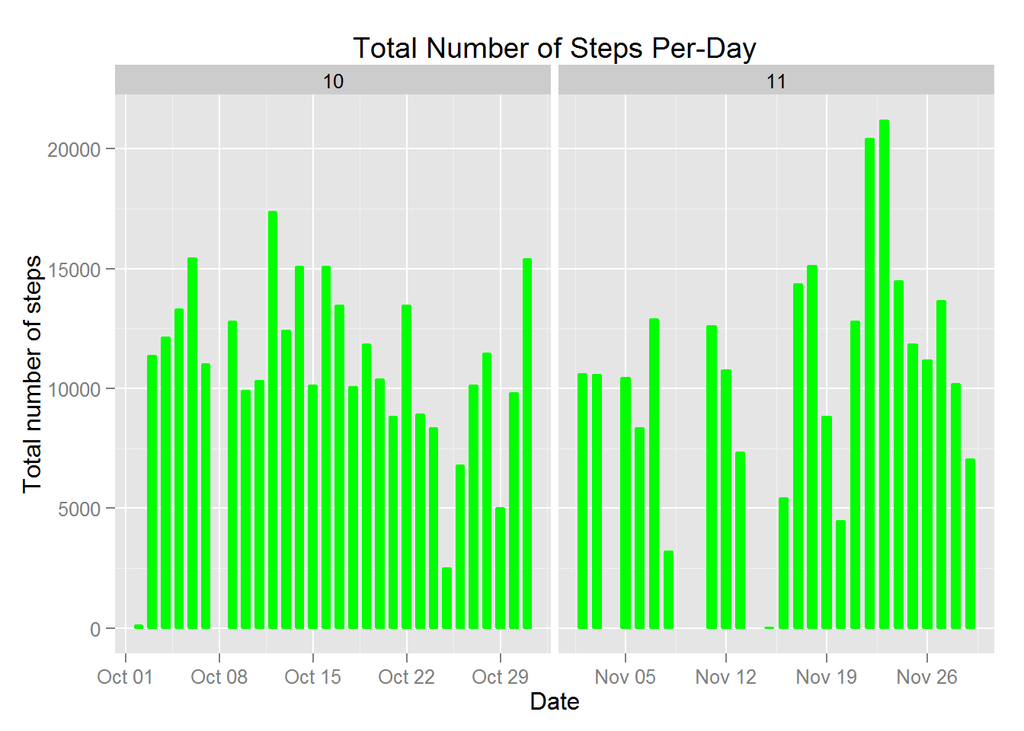

## Step 6: What is the average daily activity pattern?

1. Make a time series plot (i.e. type = “l”) of the 5-minute interval (x-axis) and the average number of steps taken, averaged across all days (y-axis)
2. Which 5-minute interval, on average across all the days in the dataset, contains the maximum number of steps?

```
## [1] 288   2
```

```
##   interval AverageSteps
## 1        0    1.7169811
## 2        5    0.3396226
## 3       10    0.1320755
## 4       15    0.1509434
## 5       20    0.0754717
## 6       25    2.0943396
```

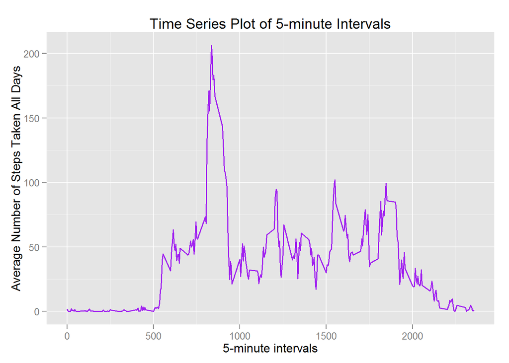

```
##     interval AverageSteps
## 104      835     206.1698
```

## Step 7: Imputing missing values

1. Calculate and report the total number of missing values in the dataset (i.e. the total number of rows with NAs)

Total number of missing value is 2304

2. Devise a strategy for filling in all of the missing values in the dataset. The strategy does not need to be sophisticated. For example, you could use the mean  
   /median for that day, or the mean for that 5-minute interval, etc. try1: use the mean for the 5 minute interval to fill in missing value for the interval try2: use the median for the 5 minute interval to fill in missing value for the interval, but per observation, a lot of rows with median value 0, so it may not  
   make sense to use median
3. Create a new dataset that is equal to the original dataset but with the missing data filled in.

```
## [1] 17568     6
```

```
##       steps       date interval month day year
## 1 1.7169811 2012-10-01        0    10   1   12
## 2 0.3396226 2012-10-01        5    10   1   12
## 3 0.1320755 2012-10-01       10    10   1   12
## 4 0.1509434 2012-10-01       15    10   1   12
## 5 0.0754717 2012-10-01       20    10   1   12
## 6 2.0943396 2012-10-01       25    10   1   12
```

```
## [1] 0
```

4. Make a histogram of the total number of steps taken each day and Calculate and report the mean and median total number of steps taken per day. Do these values differ from the estimates from the first part of the assignment? What is the impact of imputing missing data on the estimates of the total daily number of steps?

```
## [1] 10766.19
```

```
## [1] 10766.19
```

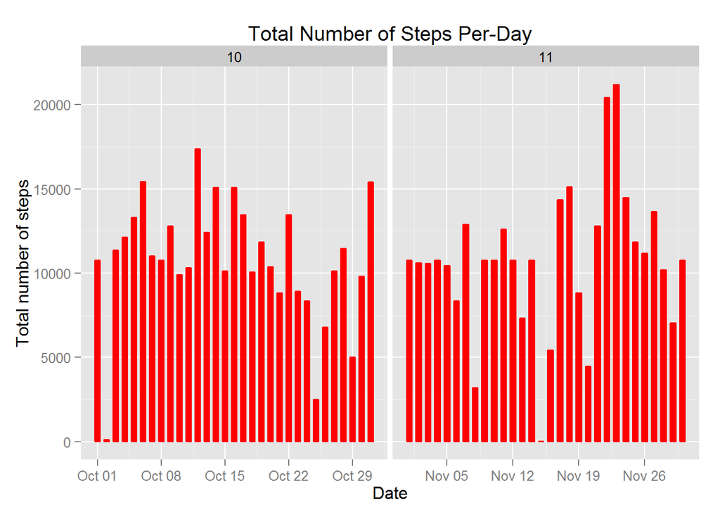

## Step 8: Are there differences in activity patterns between weekdays and weekends?

1. For this part the weekdays() function may be of some help here. Use the dataset with the filled-in missing values for this part. Create a new factor variable in the dataset with two levels – “weekday” and “weekend” indicating whether a given date is a weekday or weekend day.

```
##       steps       date interval month day year
## 1 1.7169811 2012-10-01        0    10   1   12
## 2 0.3396226 2012-10-01        5    10   1   12
## 3 0.1320755 2012-10-01       10    10   1   12
## 4 0.1509434 2012-10-01       15    10   1   12
## 5 0.0754717 2012-10-01       20    10   1   12
## 6 2.0943396 2012-10-01       25    10   1   12
```

```
##       steps       date interval month    day year   day1
## 1 1.7169811 2012-10-01        0    10 Monday   12 Monday
## 2 0.3396226 2012-10-01        5    10 Monday   12 Monday
## 3 0.1320755 2012-10-01       10    10 Monday   12 Monday
## 4 0.1509434 2012-10-01       15    10 Monday   12 Monday
## 5 0.0754717 2012-10-01       20    10 Monday   12 Monday
## 6 2.0943396 2012-10-01       25    10 Monday   12 Monday
```

```
## $weekday
## [1] "Monday"    "Tuesday"   "Wednesday" "Thursday"  "Friday"
##
## $weekend
## [1] "Saturday" "Sunday"
```

```
## [1] "weekday" "weekend"
```

```
##
##    Friday    Monday  Saturday    Sunday  Thursday   Tuesday Wednesday
##      2592      2592      2304      2304      2592      2592      2592
```

```
##
## weekday weekend
##   12960    4608
```

2. Make a panel plot containing a time series plot (i.e. type = “l”) of the 5-minute interval (x-axis) and the average number of steps taken, averaged across all weekday days or weekend days (y-axis).

```
## [1] 576   3
```

```
##   interval     day AverageSteps
## 1        0 weekday   2.25115304
## 2        5 weekday   0.44528302
## 3       10 weekday   0.17316562
## 4       15 weekday   0.19790356
## 5       20 weekday   0.09895178
## 6       25 weekday   1.59035639
```

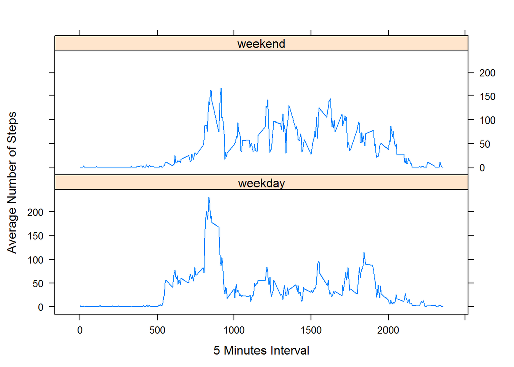